# Predicting Exercise Type with Accelerometer Data

Catie Petersen

March 15, 2017

## Summary

Dataset from: Velloso, E.; Bulling, A.; Gellersen, H.; Ugulino, W.; Fuks, H. Qualitative Activity Recognition of Weight Lifting Exercises. Proceedings of 4th International Conference in Cooperation with SIGCHI (Augmented Human ’13) . Stuttgart, Germany: ACM SIGCHI, 2013. Read more: http://groupware.les.inf.puc-rio.br/har#weight_lifting_exercises#ixzz4XJIcS33E

## Data Exploration

The testing data has several columns that aren’t populated. These columns won’t be usable for predicting a classe and will need to be removed from the training set.

## Data Cleanup

The columns that are null in the testing set are removed from the training set. The training set also has incomplete observations removed. The user name and identifier are removed as they’re not predictors of the exercise.

```r
#remove columns not used in testing data set
whichcolsneedtogo<- is.na(pml.testing[1,])
clean<-as.data.frame(pml.training[,!whichcolsneedtogo])
pml.training <- clean
pml.training$X <- NULL
pml.training$user_name <- NULL

#NAs
complete <- complete.cases(pml.training)
trainingcomplete <- pml.training[complete,]
```

## Model Building

The training data will be split to allow the model to be tested against data not used to build it.

```r
#Create testing, training, validation sets
set.seed(123)
trainIndex <- createDataPartition(trainingcomplete$classe, p = .6,
                                  list = FALSE,
                                  times = 1)
pmlTrain <- trainingcomplete[ trainIndex,]
pmlTest  <- trainingcomplete[-trainIndex,]
set.seed(123)
validIndex <- createDataPartition(pmlTest$classe, p = .5,
                                  list = FALSE,
                                  times = 1)
pmlValid <- trainingcomplete[ validIndex,]
pmlTest  <- trainingcomplete[-validIndex,]
```

Random Forest

With the number of variables and the nature of the data (classification), random forest seems and obvious possibility for predicting the classe. It is a bit challenging when running on a machine with limited memory, so the count of trees will be limited to 100 in order to avoid memory errors.

```r
#Fit random forest model to predict classe
ctrl <- trainControl(method = "cv", number = 3)

set.seed(123)
fit.random <- train(classe ~ ., data = pmlTrain, method = "rf", trControl = ctrl, ntree = 100)
random <- predict(fit.random, pmlTest)
```

Gradient Boosted Tree

Ther performance of a gradient boosted tree is usually superior to a random forest in terms of speed and memory, but it needs to be properly tuned in order to outperform a random forest in terms of accuracy. With the memory issues lessened, 200 trees will be built and the model will be built with two eta values to compare performance.

```r
#Fit boosted forest model to predict classe
xgbGrid <- expand.grid(eta = c(.1,.4), max_depth = 10, nrounds = 200, gamma = 0, colsample_bytree= 1, min_child_weight = 1)
ctrl <- trainControl(method = "cv", number = 3, classProbs = TRUE)

set.seed(123)
xgbtree.fit <- train(classe ~ ., data = pmlTrain, method = 'xgbTree', trControl = ctrl, tuneGrid = xgbGrid)
```

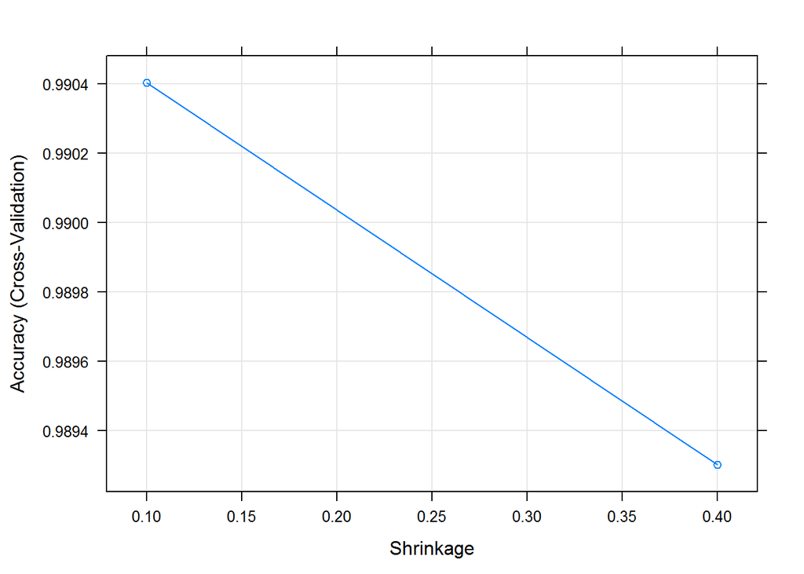

```r
plot(xgbtree.fit)
```

```r
boost <- predict(xgbtree.fit, pmlTest)
```

## Model Evaluation

```r
#Random forest
fit.random
```

```
## Random Forest
##
## 11776 samples
##    57 predictor
##     5 classes: 'A', 'B', 'C', 'D', 'E'
##
## No pre-processing
## Resampling: Cross-Validated (3 fold)
## Summary of sample sizes: 7850, 7851, 7851
## Resampling results across tuning parameters:
##
##   mtry  Accuracy   Kappa      Accuracy SD   Kappa SD
##    2    0.9863280  0.9827017  1.558378e-03  1.973676e-03
##   38    0.9974524  0.9967776  3.746704e-07  5.320803e-07
##   75    0.9971977  0.9964553  6.739297e-04  8.526349e-04
##
## Accuracy was used to select the optimal model using  the largest value.
## The final value used for the model was mtry = 38.
```

```r
confusionMatrix(random, pmlTest$classe)
```

```
## Confusion Matrix and Statistics
##
##           Reference
## Prediction    A    B    C    D    E
##          A 2790    0    0    0    0
##          B    0 2664    2    0    0
##          C    0    0 3416    0    0
##          D    0    0    4 3216    0
##          E    0    0    0    0 3607
##
## Overall Statistics
##
##                Accuracy : 0.9996
##                  95% CI : (0.9992, 0.9999)
##     No Information Rate : 0.2298
##     P-Value [Acc > NIR] : < 2.2e-16
##
##                   Kappa : 0.9995
##  Mcnemar's Test P-Value : NA
##
## Statistics by Class:
##
##                      Class: A Class: B Class: C Class: D Class: E
## Sensitivity            1.0000   1.0000   0.9982   1.0000   1.0000
## Specificity            1.0000   0.9998   1.0000   0.9997   1.0000
## Pos Pred Value         1.0000   0.9992   1.0000   0.9988   1.0000
## Neg Pred Value         1.0000   1.0000   0.9995   1.0000   1.0000
## Prevalence             0.1777   0.1697   0.2180   0.2049   0.2298
## Detection Rate         0.1777   0.1697   0.2176   0.2049   0.2298
## Detection Prevalence   0.1777   0.1698   0.2176   0.2051   0.2298
## Balanced Accuracy      1.0000   0.9999   0.9991   0.9998   1.0000
```

```r
#Gradient Boosted Tree
xgbtree.fit
```

```
## eXtreme Gradient Boosting
##
## 11776 samples
##    57 predictor
##     5 classes: 'A', 'B', 'C', 'D', 'E'
##
## No pre-processing
## Resampling: Cross-Validated (3 fold)
## Summary of sample sizes: 7850, 7851, 7851
## Resampling results across tuning parameters:
##
##   eta  Accuracy   Kappa      Accuracy SD   Kappa SD
##   0.1  0.9904043  0.9878641  0.0019778053  0.0024997690
##   0.4  0.9893003  0.9864672  0.0007628715  0.0009638866
##
## Tuning parameter 'nrounds' was held constant at a value of 200
##
## Tuning parameter 'colsample_bytree' was held constant at a value of
##  1
## Tuning parameter 'min_child_weight' was held constant at a value of 1
## Accuracy was used to select the optimal model using  the largest value.
## The final values used for the model were nrounds = 200, max_depth =
##  10, eta = 0.1, gamma = 0, colsample_bytree = 1 and min_child_weight = 1.
```

```r
confusionMatrix(boost, pmlTest$classe)
```

```
## Confusion Matrix and Statistics
##
##           Reference
## Prediction    A    B    C    D    E
##          A 2789    1    0    0    0
##          B    0 2629    7    1    0
##          C    1   34 3410    6    0
##          D    0    0    5 3209    4
##          E    0    0    0    0 3603
##
## Overall Statistics
##
##                Accuracy : 0.9962
##                  95% CI : (0.9952, 0.9971)
##     No Information Rate : 0.2298
##     P-Value [Acc > NIR] : < 2.2e-16
##
##                   Kappa : 0.9953
##  Mcnemar's Test P-Value : NA
##
## Statistics by Class:
##
##                      Class: A Class: B Class: C Class: D Class: E
## Sensitivity            0.9996   0.9869   0.9965   0.9978   0.9989
## Specificity            0.9999   0.9994   0.9967   0.9993   1.0000
## Pos Pred Value         0.9996   0.9970   0.9881   0.9972   1.0000
## Neg Pred Value         0.9999   0.9973   0.9990   0.9994   0.9997
## Prevalence             0.1777   0.1697   0.2180   0.2049   0.2298
## Detection Rate         0.1777   0.1675   0.2172   0.2044   0.2295
## Detection Prevalence   0.1777   0.1680   0.2198   0.2050   0.2295
## Balanced Accuracy      0.9998   0.9931   0.9966   0.9986   0.9994
```

## Out of Sample Error

```r
oose <- predict(xgbtree.fit, pmlValid)
sum(oose == pmlValid$classe)/nrow(pmlValid)
```

```
## [1] 0.9951568
```

## Model selection

Since both models are performing with nearly perfect accuracy, I’ll pick the one that’s less demanding on my machine. The gradient boosted tree is much more efficient. I can build up to 400 trees with 8GB of memory while the random forest tops out at 150 trees (random forest builds with full trees, making it more demanding of resources). While the random forest is slightly more accurate, it’s within rounding error and the efficient performance is of more value then the slight uptick in accuracy.

## Test Data

The gradient boosted model is used to predict the classe given the measurements from the accelerometers.

```r
results <- predict(xgbtree.fit, pml.testing)
```